# Similarities in the 2012 PISA between Mexico, Japan and the United Kingdom

## by Alfonso Sanchez

## Introduction

> The Programme International Student Assessment (PISA), implemented by the Organization for Economic Co-operation and Development (OECD), allows the comparison of the education provided by the different countries that are part of it. This assessment measures the academic performance of 15-year-old students in three different disciplines, Mathematics, Reading and Science. The PISA exam is important since helps the OECD countries to improve their politics about education, given that the exam does not evaluate the students, but the educational system provided for each of the OECD countries.

## Investigation Overview

> The objective of this presentation is to find factors that affect the performance of students when taking the PISA assessment. The factors evaluated were provided from the results of the 2012 PISA exam. The study was implemented considering only results obtained from Mexican, Japanese and British students. The countries selected for this study were chosen to compare their student's performances during the PISA assessment, to compare students from countries with results above the average, with average results and with results below the average.

## Dataset Overview

> The dataset used in this Study is composed of results obtained from the implementation of the PISA assessment in 2012. The dataset has information from the 36 countries that form the OECD. It contains the performance of students when solving Mathematical, Reading and Science related problems. Additionally, it contains information about their parents' education, occupations, facilities to study in their homes, how much time the students learn outside the school, their ages, genders, among other interesting features.

## Univariate Analysis

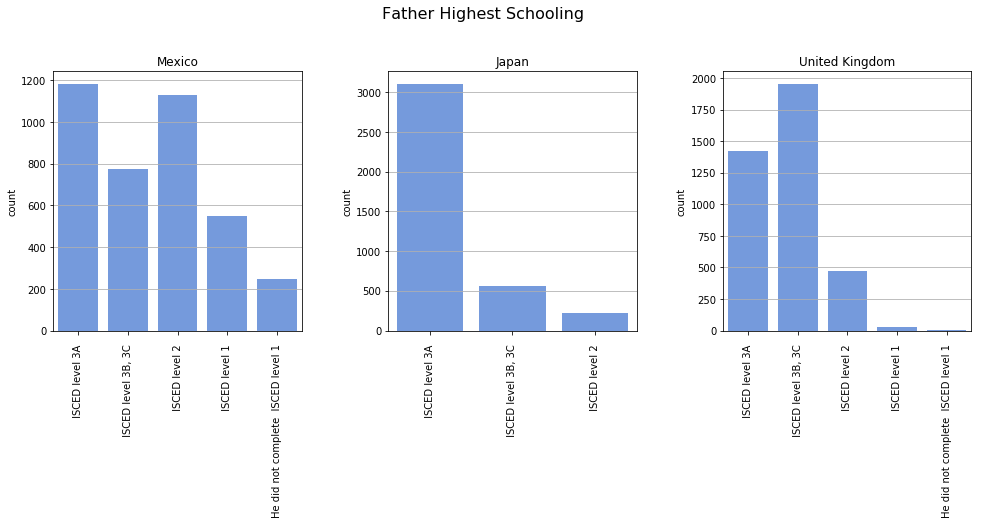

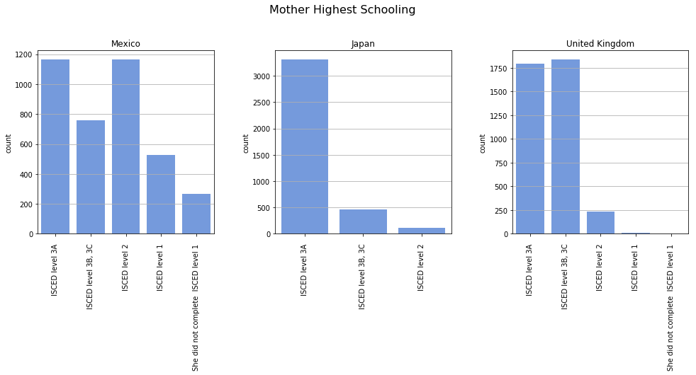

## Bivariate Analysis

> The differences in the parent's education of students from the selected OECD countries do not necessarily are related with results obtained during the PISA exam. For that reason, it is required a deeper analysis. The figures below present relationships among the parent’s levels of education and the results obtained from the selected students. It is considered only the Mathematical section of the PISA exam.

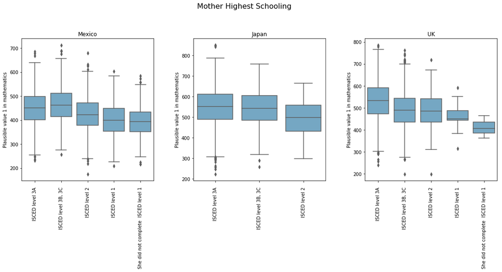

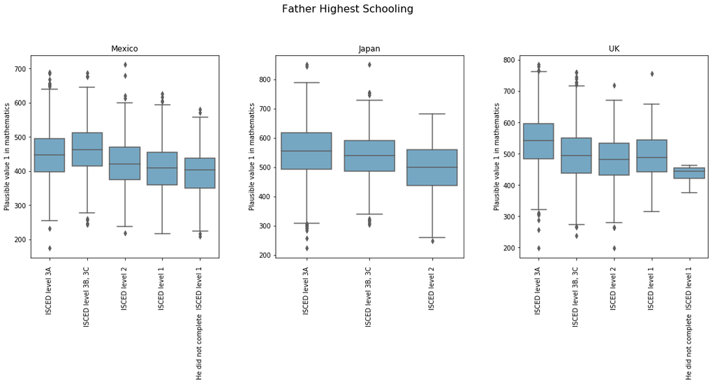

## Multivariate Analysis

Results obtained in the previous sections show that the scores that students from the selected countries obtained in the PISA exam depends on different factors, at least for the mathematical section of the exam. Therefore, it is required to prove that the effect on the rest of the sections is similar but most important, it is necessary to demonstrate that the different features obtained during the PISA assessment affect students from the selected countries in the same way. The following figures compare results obtained from students of the selected countries when solving the different sections of the 2012 PISA assessment. The last figure presents the amount of correlation between them.

It can be observed in the next figure that results for the different sections of the PISA exam are highly related among students of the same country. That is not the case from students of different countries, where results obtained by them are not related at all.

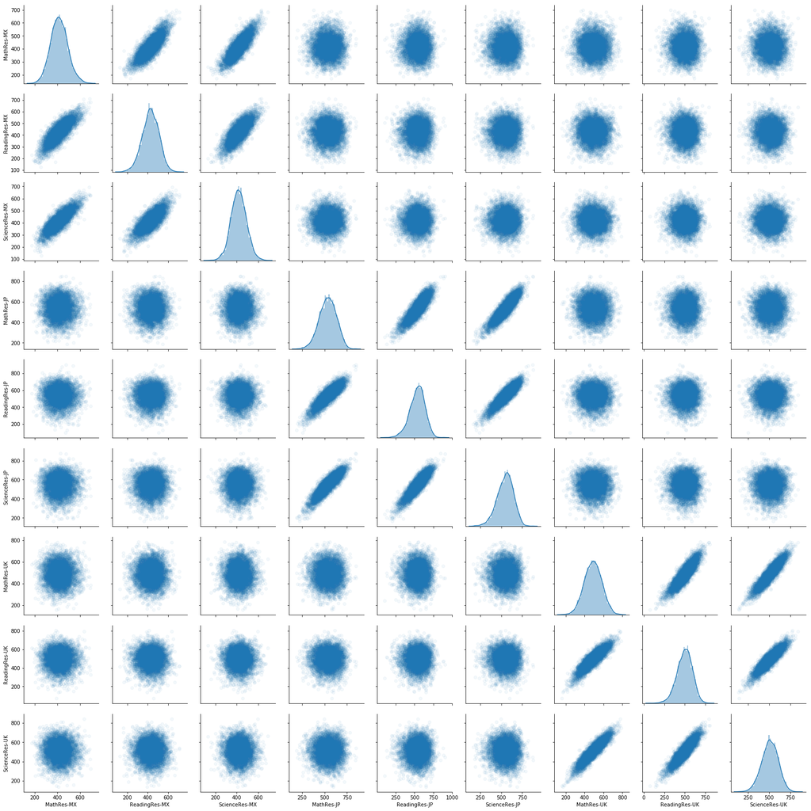

There exist high correlations among results for the different sections of the PISA exam obtained from students of the same country. However, results from students of different countries are almost uncorrelated. Moreover, the amount of correlation between results for the different sections of the PISA exam is higher for Japanese and British students when compared against the amount of correlation for Mexican students.

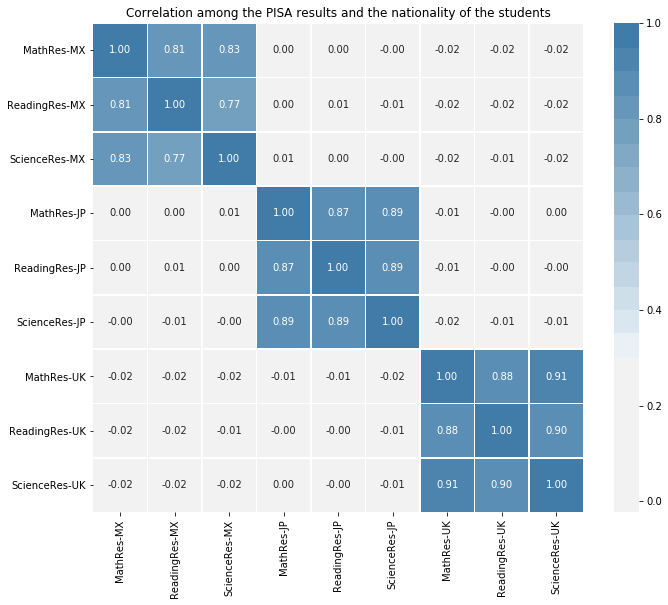